# PROTAC linker enumeration

Cheminformatics

Create PROTAC linker library with different linker length and composition

Author

Samdani Ansar

Published

May 21, 2023

To run the notebook in Google Colab.

# PROTAC

PROTAC is a class of small-molecule compounds designed to target and degrade specific proteins within cells. It is a strategy used in drug development to selectively remove disease-causing proteins by utilizing the cell’s own protein degradation machinery.

The typical structure of a PROTAC molecule consists of three main components: a ligand for the target protein (called the “targeting moiety”), a ligand for an E3 ubiquitin ligase enzyme (called the “recruiting moiety”), and a linker connecting the two moieties.

The idea behind PROTACs is that they can bind to both the target protein and the E3 ubiquitin ligase simultaneously. This interaction leads to the transfer of ubiquitin molecules from the E3 ligase to the target protein, resulting in the labeling of the target protein for degradation by the proteasome. As a result, the target protein is degraded, leading to its functional inactivation.

PROTACs have gained significant attention in the field of drug discovery and have shown promise in targeting various disease-causing proteins, including cancer-related proteins and other therapeutic targets. They offer a potential alternative to traditional small-molecule inhibitors, which often only block the activity of the target protein without leading to its degradation.

For more information on PROTAC can be obtained thorugh fiew review papers [1],[2]

The post describes how the rdkit can be used for create PROTAC with different linker length and also with different linker compoistion between the target and ligase ligand.

```python
from rdkit import Chem
from rdkit.Chem import Draw
from rdkit.Chem.Draw import IPythonConsole
from rdkit.Chem import PandasTools
import pandas as pd
from IPython.core.display import HTML
# IPythonConsole.drawOptions.addAtomIndices = True
IPythonConsole.molSize = 300,300

from rdkit import RDLogger
RDLogger.DisableLog('rdApp.*')

def mol_with_atom_index(mol):
    for atom in mol.GetAtoms():
        atom.SetAtomMapNum(atom.GetIdx())
    return mol
```

# Load the target ligand

```python
target = Chem.MolFromSmiles('Cc1sc-2c(c1C)C(=N[C@@H](CC(=O)N-*)c1nnc(C)n-21)c1ccc(Cl)cc1')
target
```

[figure not shown]

# Load the ligase ligand

```python
VHL_lig = Chem.MolFromSmiles('CC1=C(SCN1)c1ccc(CNC(=O)[C@@H]2C[C@@H](O)CN2C(=O)[C@@H](NC(-*)=O)C(C)(C)C)cc1')
CRBN_lig = Chem.MolFromSmiles('*-NC(=O)COc1cccc2C(=O)N([C@H]3CCC(=O)NC3=O)C(=O)c12')

LIGASE = [VHL_lig, CRBN_lig]
```

```python
VHL_lig
```

[figure not shown]

```python
CRBN_lig
```

[figure not shown]

```python
LINKERS = {
    'LINK1':'*-C-*','LINK2':'*-OCCO-*','LINK3':'*-N1CCN(-*)CC1','LINK4':'*-C1CCN(-*)CC1',
    'LINK5':'*-N1C=C(-*)C=N1','LINK6':'*-C#CC1=CN(-*)N=C1','LINK7':'*-CCOCC-*','LINK8':'*-C1=CC=C(-*)C=C1',
    'LINK9':'*-C1=CC(-*)=CC=C1','LINK10':'*-C1=C(-*)C=CC=C1','LINK11':'*-C#C-*','LINK12':'*-OC1=CC=C(-*)C=C1',
    'LINK13':'*-C1=CC(-*)=CN1','LINK14':'*-NCC1=CC=C(-*)C=C1','LINK15':'*-CO-*'}
```

Smiles

ROMol

LINK1

*-C-*

LINK2

*-OCCO-*

LINK3

*-N1CCN(-*)CC1

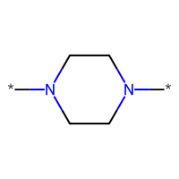

LINK4

*-C1CCN(-*)CC1

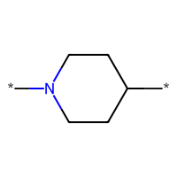

LINK5

*-N1C=C(-*)C=N1

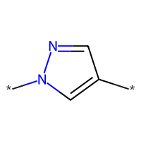

LINK6

*-C#CC1=CN(-*)N=C1

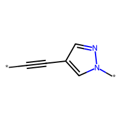

LINK7

*-CCOCC-*

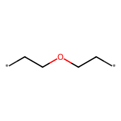

LINK8

*-C1=CC=C(-*)C=C1

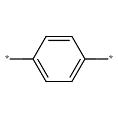

LINK9

*-C1=CC(-*)=CC=C1

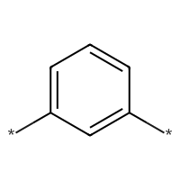

LINK10

*-C1=C(-*)C=CC=C1

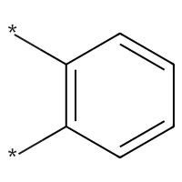

LINK11

*-C#C-*

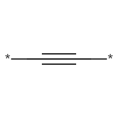

LINK12

*-OC1=CC=C(-*)C=C1

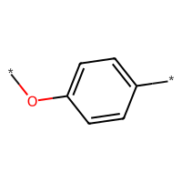

LINK13

*-C1=CC(-*)=CN1

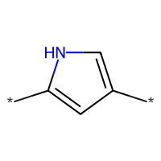

LINK14

*-NCC1=CC=C(-*)C=C1

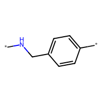

LINK15

*-CO-*

[1 more figures not shown]

```python
df = pd.DataFrame.from_dict(LINKERS, orient='index',columns=['Smiles'])
PandasTools.AddMoleculeColumnToFrame(df,'Smiles')
HTML(df.to_html(notebook=True))
```

```python
# Functions for generating the linker library

def get_atom_index(mol):
    # Get linking position atom index
    link_atom_index = []
    for atom in mol.GetAtoms():
        if atom.GetSymbol() == '*':
            link_atom_index.append(atom.GetIdx())
    return link_atom_index

def delete_last_atom(mol,del_atoms=1):
    first_mol = Chem.RWMol(mol)
    input_idx = [atom.GetIdx() for atom in first_mol.GetAtoms()]
    link_mol = Chem.EditableMol(mol)
    link_mol.RemoveAtom(input_idx[-1]) #Remove last atom
    first_mol = link_mol.GetMol()
    return first_mol

def generate_polymer(input_mol,num=1,del_atoms=1):
    # Frag for polymer
    frag_mol = Chem.RWMol(input_mol)
    input_idx = [atom.GetIdx() for atom in frag_mol.GetAtoms()]
    for deln in range(del_atoms):
        link_mol = Chem.EditableMol(frag_mol)
        link_mol.RemoveAtom(input_idx[0]) # Remove first atom for the fragment polymer
        frag_mol = link_mol.GetMol()
    linker = ''
    for inum in range(num):
        if not linker:
            linker = Chem.RWMol(input_mol)
        else:
            linker = delete_last_atom(linker,del_atoms=del_atoms)
            linker = Chem.CombineMols(linker,frag_mol)
            link_idx = []
            for atom in linker.GetAtoms():
                if (atom.GetAtomicNum() != 0) and (len(atom.GetNeighbors()) == 1):
                    link_idx.append(atom.GetIdx())
            link_mol = Chem.EditableMol(linker)
            link_mol.AddBond(link_idx[0],link_idx[1],order=Chem.rdchem.BondType.SINGLE)
            linker = link_mol.GetMol()
    return linker
def combine_frags(front_mol,middle_mol):
    Front_idx = [ atom.GetIdx() for atom in front_mol.GetAtoms() if (atom.GetAtomicNum() == 0)]
    if len(Front_idx) == 1:
        F_index = Front_idx[0]
    else:
        F_index = Front_idx[1]
    Front_neighbor = front_mol.GetAtomWithIdx(F_index).GetNeighbors()[0].GetIdx()
    Middle_idx = [ atom.GetIdx() for atom in middle_mol.GetAtoms() if (atom.GetAtomicNum() == 0)]
    Middle_neighbor = middle_mol.GetAtomWithIdx(Middle_idx[0]).GetNeighbors()[0].GetIdx()
    merge_mol = Chem.CombineMols(front_mol,middle_mol)
    link_mol = Chem.EditableMol(merge_mol)
    link_mol.AddBond(Front_neighbor,Middle_neighbor+front_mol.GetNumAtoms(),order=Chem.rdchem.BondType.SINGLE)
    link_mol.RemoveAtom(Middle_idx[0]+front_mol.GetNumAtoms()) # Delete larger index number first
    link_mol.RemoveAtom(F_index)
    merge_mol = link_mol.GetMol()
    return merge_mol
```

# Generate methyl linker

Here, we will generate different length of methyl linkers which connects between the target and ligase ligand.

```python
def generate_methyl_linker(num=1):
    methyl = Chem.MolFromSmiles('*-C-*')
    linker_lib = []
    for idx in range(1,num+1):
        linker = generate_polymer(methyl,num=idx,del_atoms=1)
        linker_lib.append(linker)
    return linker_lib

linker_lib = generate_methyl_linker(num=3)
Draw.MolsToGridImage(linker_lib, molsPerRow=3, subImgSize=(350, 200))
```

[figure not shown]

```python
target = Chem.MolFromSmiles('Cc1sc-2c(c1C)C(=N[C@@H](CC(=O)N-*)c1nnc(C)n-21)c1ccc(Cl)cc1')
VHL_lig = Chem.MolFromSmiles('CC1=C(SCN1)c1ccc(CNC(=O)[C@@H]2C[C@@H](O)CN2C(=O)[C@@H](NC(-*)=O)C(C)(C)C)cc1')
CRBN_lig = Chem.MolFromSmiles('*-NC(=O)COc1cccc2C(=O)N([C@H]3CCC(=O)NC3=O)C(=O)c12')
LIGASE=[VHL_lig,CRBN_lig]

PROTAC_lib = []
for linker in linker_lib:
    for Li in LIGASE:
        combine_mol1 = combine_frags(target,linker)
        combine_mol2 = combine_frags(combine_mol1,Li)
        PROTAC_lib.append([Chem.MolToSmiles(target),Chem.MolToSmiles(Li),Chem.MolToSmiles(linker),Chem.MolToSmiles(combine_mol2)])
PROTAC_DICT = pd.DataFrame(columns=['target','ligase','linker','protac'])
for i in PROTAC_lib:
    TEMP_DICT = pd.DataFrame(dict(zip(['target','ligase','linker','protac'],i)),index=[0])
    PROTAC_DICT = pd.concat([PROTAC_DICT,TEMP_DICT], ignore_index=True)
PROTAC_DICT
```

|  | target | ligase | linker | protac |
| --- | --- | --- | --- | --- |
| 0 | *NC(=O)C[C@@H]1N=C(c2ccc(Cl)cc2)c2c(sc(C)c2C)-... | *C(=O)N[C@H](C(=O)N1C[C@H](O)C[C@H]1C(=O)NCc1c... | *C* | CC1=C(c2ccc(CNC(=O)[C@@H]3C[C@@H](O)CN3C(=O)[C... |
| 1 | *NC(=O)C[C@@H]1N=C(c2ccc(Cl)cc2)c2c(sc(C)c2C)-... | *NC(=O)COc1cccc2c1C(=O)N([C@H]1CCC(=O)NC1=O)C2=O | *C* | Cc1sc2c(c1C)C(c1ccc(Cl)cc1)=N[C@@H](CC(=O)NCNC... |
| 2 | *NC(=O)C[C@@H]1N=C(c2ccc(Cl)cc2)c2c(sc(C)c2C)-... | *C(=O)N[C@H](C(=O)N1C[C@H](O)C[C@H]1C(=O)NCc1c... | *CC* | CC1=C(c2ccc(CNC(=O)[C@@H]3C[C@@H](O)CN3C(=O)[C... |
| 3 | *NC(=O)C[C@@H]1N=C(c2ccc(Cl)cc2)c2c(sc(C)c2C)-... | *NC(=O)COc1cccc2c1C(=O)N([C@H]1CCC(=O)NC1=O)C2=O | *CC* | Cc1sc2c(c1C)C(c1ccc(Cl)cc1)=N[C@@H](CC(=O)NCCN... |
| 4 | *NC(=O)C[C@@H]1N=C(c2ccc(Cl)cc2)c2c(sc(C)c2C)-... | *C(=O)N[C@H](C(=O)N1C[C@H](O)C[C@H]1C(=O)NCc1c... | *CCC* | CC1=C(c2ccc(CNC(=O)[C@@H]3C[C@@H](O)CN3C(=O)[C... |
| 5 | *NC(=O)C[C@@H]1N=C(c2ccc(Cl)cc2)c2c(sc(C)c2C)-... | *NC(=O)COc1cccc2c1C(=O)N([C@H]1CCC(=O)NC1=O)C2=O | *CCC* | Cc1sc2c(c1C)C(c1ccc(Cl)cc1)=N[C@@H](CC(=O)NCCC... |

target

ligase

linker

protac

0

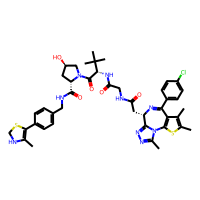

1

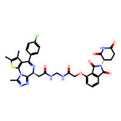

2

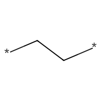

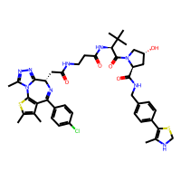

3

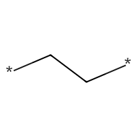

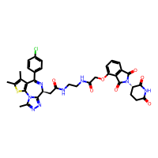

4

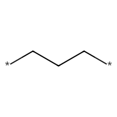

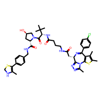

5

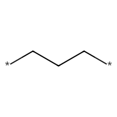

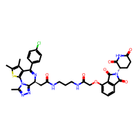

```python
from rdkit.Chem import PandasTools
import pandas as pd
from IPython.core.display import HTML

PandasTools.AddMoleculeColumnToFrame(PROTAC_DICT, smilesCol='target', molCol='target')
PandasTools.AddMoleculeColumnToFrame(PROTAC_DICT, smilesCol='ligase', molCol='ligase')
PandasTools.AddMoleculeColumnToFrame(PROTAC_DICT, smilesCol='linker', molCol='linker')
PandasTools.AddMoleculeColumnToFrame(PROTAC_DICT, smilesCol='protac', molCol='protac')

PandasTools.RenderImagesInAllDataFrames(images=True)
HTML(PROTAC_DICT.to_html(notebook=True))
```

# Generate PEG linker

Here, we will generate different length of PEG linkers which connects between the target and ligase ligand.

```python
def generate_peg_linker(num=1):
    linker_lib = []
    peg = Chem.MolFromSmiles('*-OCCO-*')
    for idx in range(1,num+1):
        linker = generate_polymer(peg,num=idx,del_atoms=2)
        linker_lib.append(linker)
    return linker_lib
linker_lib = generate_peg_linker(num=3) # Generate peg library
Draw.MolsToGridImage(linker_lib, molsPerRow=3, subImgSize=(350, 200))
```

[figure not shown]

```python
target = Chem.MolFromSmiles('Cc1sc-2c(c1C)C(=N[C@@H](CC(=O)N-*)c1nnc(C)n-21)c1ccc(Cl)cc1')
VHL_lig = Chem.MolFromSmiles('CC1=C(SCN1)c1ccc(CNC(=O)[C@@H]2C[C@@H](O)CN2C(=O)[C@@H](NC(-*)=O)C(C)(C)C)cc1')
CRBN_lig = Chem.MolFromSmiles('*-NC(=O)COc1cccc2C(=O)N([C@H]3CCC(=O)NC3=O)C(=O)c12')
LIGASE=[VHL_lig,CRBN_lig]

PROTAC_lib = []
for linker in linker_lib:
    for Li in LIGASE:
        combine_mol1 = combine_frags(target,linker) # Combine Target ligand and linker
        combine_mol2 = combine_frags(combine_mol1,Li) # Combine target-ligand_linker and ligase ligand
        PROTAC_lib.append([Chem.MolToSmiles(target),Chem.MolToSmiles(Li),Chem.MolToSmiles(linker),Chem.MolToSmiles(combine_mol2)])
PROTAC_DICT = pd.DataFrame(columns=['target','ligase','linker','protac'])
for i in PROTAC_lib:
    TEMP_DICT = pd.DataFrame(dict(zip(['target','ligase','linker','protac'],i)),index=[0])
    PROTAC_DICT = pd.concat([PROTAC_DICT,TEMP_DICT], ignore_index=True)
PROTAC_DICT
```

|  | target | ligase | linker | protac |
| --- | --- | --- | --- | --- |
| 0 | *NC(=O)C[C@@H]1N=C(c2ccc(Cl)cc2)c2c(sc(C)c2C)-... | *C(=O)N[C@H](C(=O)N1C[C@H](O)C[C@H]1C(=O)NCc1c... | *OCCO* | CC1=C(c2ccc(CNC(=O)[C@@H]3C[C@@H](O)CN3C(=O)[C... |
| 1 | *NC(=O)C[C@@H]1N=C(c2ccc(Cl)cc2)c2c(sc(C)c2C)-... | *NC(=O)COc1cccc2c1C(=O)N([C@H]1CCC(=O)NC1=O)C2=O | *OCCO* | Cc1sc2c(c1C)C(c1ccc(Cl)cc1)=N[C@@H](CC(=O)NOCC... |
| 2 | *NC(=O)C[C@@H]1N=C(c2ccc(Cl)cc2)c2c(sc(C)c2C)-... | *C(=O)N[C@H](C(=O)N1C[C@H](O)C[C@H]1C(=O)NCc1c... | *OCCOCCO* | CC1=C(c2ccc(CNC(=O)[C@@H]3C[C@@H](O)CN3C(=O)[C... |
| 3 | *NC(=O)C[C@@H]1N=C(c2ccc(Cl)cc2)c2c(sc(C)c2C)-... | *NC(=O)COc1cccc2c1C(=O)N([C@H]1CCC(=O)NC1=O)C2=O | *OCCOCCO* | Cc1sc2c(c1C)C(c1ccc(Cl)cc1)=N[C@@H](CC(=O)NOCC... |
| 4 | *NC(=O)C[C@@H]1N=C(c2ccc(Cl)cc2)c2c(sc(C)c2C)-... | *C(=O)N[C@H](C(=O)N1C[C@H](O)C[C@H]1C(=O)NCc1c... | *OCCOCCOCCO* | CC1=C(c2ccc(CNC(=O)[C@@H]3C[C@@H](O)CN3C(=O)[C... |
| 5 | *NC(=O)C[C@@H]1N=C(c2ccc(Cl)cc2)c2c(sc(C)c2C)-... | *NC(=O)COc1cccc2c1C(=O)N([C@H]1CCC(=O)NC1=O)C2=O | *OCCOCCOCCO* | Cc1sc2c(c1C)C(c1ccc(Cl)cc1)=N[C@@H](CC(=O)NOCC... |

target

ligase

linker

protac

0

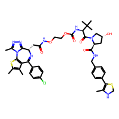

1

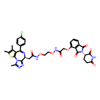

2

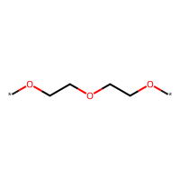

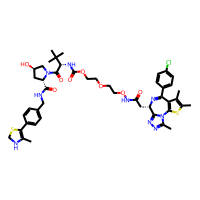

3

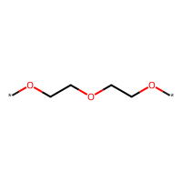

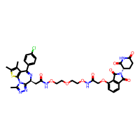

4

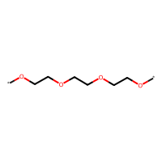

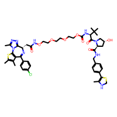

5

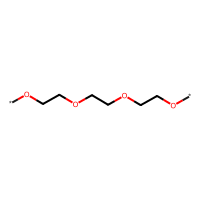

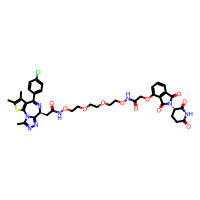

```python
from rdkit.Chem import PandasTools
import pandas as pd
from IPython.core.display import HTML

PandasTools.AddMoleculeColumnToFrame(PROTAC_DICT, smilesCol='target', molCol='target')
PandasTools.AddMoleculeColumnToFrame(PROTAC_DICT, smilesCol='ligase', molCol='ligase')
PandasTools.AddMoleculeColumnToFrame(PROTAC_DICT, smilesCol='linker', molCol='linker')
PandasTools.AddMoleculeColumnToFrame(PROTAC_DICT, smilesCol='protac', molCol='protac')

PandasTools.RenderImagesInAllDataFrames(images=True)
HTML(PROTAC_DICT.to_html(notebook=True))
```